# Time-series clustering

Dr. Ana Rita Marques amarques@upei.ca

UPEI EPI on the Island Module 2- 2018

- Clustering is an unsupervised data mining technique.
- The goal is to form homogeneous groups, or clusters of objects, with minimum inter-cluster and maximum intra-cluster similarity.
- An exploratory technique in time-series visualization.
- Construct clusters as you consider the entire series as a whole.

To start, choose 3 main parameters.

1. Distance measure (quantify dissimilarity)
2. Prototype (summarizes characteristics of all series in a cluster)
3. Cluster algorithm (most common partitional or hierarchical)

To finish, evaluate results.

1. Cluster validity indices (CVI)

## I. Distance measures

1. Euclidean distance
- most commonly used distance measure
- main limitations:
  - only for series of equal length
  - sensitive to time shifts
2. Dynamic time warping (DTW) distance
- shape based; overcomes Euclidean distance limitations
- algorithm compares two series to find the optimum warping path
- creates a local cost matrix and traverses it to find the optimal warping path
- needs/constraints:
  - choice of step pattern
  - choice of window that limits the area of the LCM (unknown *a priori*, so test for best size)
  - can handle series with unequal length (slanted band vs. Sakoe-Chiba window)
  - minimum alignment and divergence functions, Eq. 1.1 and 1.2
  - computationally expensive
  - (*)

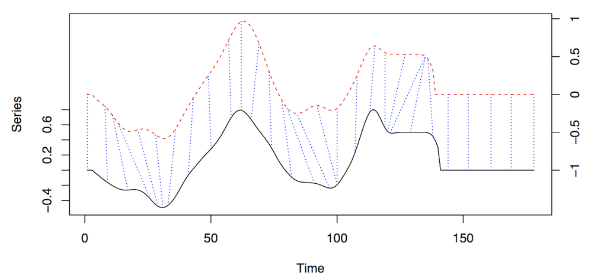

3. Global alignment kernel (GAK) distance
- similarity between time series by using kernels
- uses a local similarity function (in Eq. 2)
- again, get the best path at the lowest cost (soft-minimum of all alignment scores)

$$DTW(x,y) = min_{\pi \in \Lambda (n,m)} D_{x,y}(\pi)$$
(1.1)
$$DTW(x,y) = \sum_{i=1}^{|\pi|} \varphi(x_{\pi_1 (i)}, y_{\pi_2 (i)})$$
(1.2)
$$\kappa_{GA}= \sum_{\pi \in \Lambda (n,m)}\prod_{i=1}^{|\pi|}\ K (x_{\pi_1 (i)}, y_{\pi_2 (i)})$$
(2)

- alignment between two time series x and y of lengths n and m

## II. Prototype

1. Mean or median
- the average of each time-point
- poor choice (affect convergence)
- only for series of equal length
2. Partition around medoids (PAM)
- the medoid is the prototype of the cluster that is one of the time series itself
- facilitates computation (“re-usable”)
3. DTW barycenter averaging
4. Shape extraction
5. Fuzzy-based prototypes

*Note*

- for hierarchical clustering with DTW, if one wished to obtain the prototype of the series for further characterization, this must be obtained using mean or preferably another shape-based approach.(*)
- may require *z*-normalization to output mean zero and s.d. 1; recommended for structural vs. amplitude driven change detection (among other exceptions, always include when function output is normalized). See zscore function.
- may require that time-series have equal length. See reinterpolate function for a possible solution using linear interpolation.

## III. Time-series clustering algorithms

1. Hierarchical clustering
- hierarchical grouping to form clusters
- agglomerative
- need to specify the pairwise similarities (i.e. DTW) and the similarity measure between groups (linkage method)
- linkage methods: *i.e.* single (closest pair), complete (furthest pair)(*), Diana, Wards
- hierarchical *vs* partitional -> no needed pre-specification of *k* clusters
- produces a dendrogram from where the best *k* clusters can be deduced (*vs* CVI’s)
2. Partitional clustering
- (*k*) random [centroids](http://rstudio-pubs-static.s3.amazonaws.com/series_centroid.png) are initialized, distance to all data is determined and objects are assigned to each cluster (iterative)
- main disadvantages:
  1. pre-specify *k*
  2. stochastic, random start and may converge at a local *optima*
- advantages: best for larger data sets.

*Note*

- (*) generally preferred; compact clusters
- a pretty cluster result would look like this:

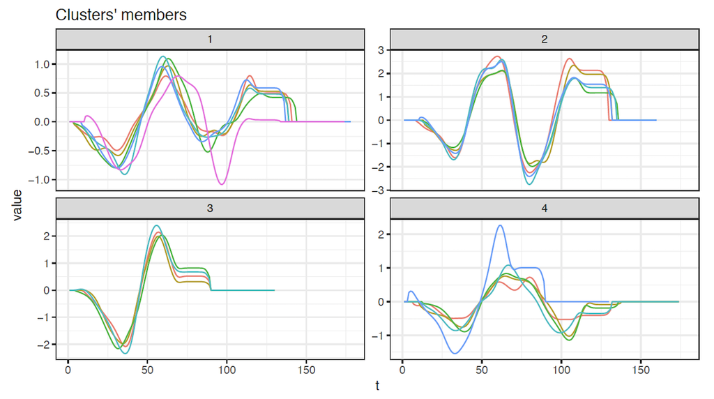